# **YouTube Trending Videos Data Analysis**

This project aims to analyze datasets containing daily trending YouTube videos. The dataset includes data from Great Britain, USA, Canada, Germany, France, South Korea, Russia, India, Mexico, and Japan. YouTube compiles a list of top trending videos, and this dataset covers several months of such trending YouTube videos.

The list is determined based on factors such as comments, views, and likes on the videos over time to identify the most popular ones. Videos are ranked according to criteria including comments, likes, the number of views, and the number of times they have been shared in order to showcase the top trending videos.

## **Importing libraries**

```python
import numpy as np
import re
import pandas as pd
import matplotlib.pyplot as plt
%matplotlib inline
import seaborn as sns
from matplotlib import cm
from datetime import datetime
import glob
import os
import json
import pickle
import six
sns.set()
pd.set_option('display.max_columns', None)
pd.set_option('display.max_rows', None)
pd.options.mode.chained_assignment = None


import warnings
warnings.filterwarnings('ignore')
```

## **Importing Dataset**

```python
os.chdir( 'Dataset' )
```

### **Importing all the CSV files**

**Glob** Glob (short for global) is used to return all file paths that match a specific pattern.

```python
AllCSV = [i for i in glob.glob('*.{}'.format('csv'))]
```

```python
AllCSV
```

```
['CAvideos.csv',
 'DEvideos.csv',
 'GBvideos.csv',
 'FRvideos.csv',
 'INvideos.csv',
 'JPvideos.csv',
 'MXvideos.csv',
 'KRvideos.csv',
 'RUvideos.csv',
 'USvideos.csv']
```

## **Reading all CSV files**

1. Reading a CSV file into Dataframes
2. Appending all country Dataframes to a list of all_dataframes:

```python
all_dataframes=[]
for csv in AllCSV:
    df=pd.read_csv(csv, encoding='latin-1')
    df['country']=csv[0:2]
    all_dataframes.append(df)
```

**all_dataframes.head()** is showing top 10 records from the 0th index of all_dataframes.

```python
all_dataframes[0].head(10)
```

|  | video_id | trending_date | title | channel_title | category_id | publish_time | tags | views | likes | dislikes | comment_count | thumbnail_link | comments_disabled | ratings_disabled | video_error_or_removed | description | country |
| --- | --- | --- | --- | --- | --- | --- | --- | --- | --- | --- | --- | --- | --- | --- | --- | --- | --- |
| 0 | n1WpP7iowLc | 17.14.11 | Eminem - Walk On Water (Audio) ft. Beyoncé | EminemVEVO | 10 | 2017-11-10T17:00:03.000Z | Eminem\|"Walk"\|"On"\|"Water"\|"Aftermath/Shady/In... | 17158579 | 787425 | 43420 | 125882 | https://i.ytimg.com/vi/n1WpP7iowLc/default.jpg | False | False | False | Eminem's new track Walk on Water ft. Beyoncé ... | CA |
| 1 | 0dBIkQ4Mz1M | 17.14.11 | PLUSH - Bad Unboxing Fan Mail | iDubbbzTV | 23 | 2017-11-13T17:00:00.000Z | plush\|"bad unboxing"\|"unboxing"\|"fan mail"\|"id... | 1014651 | 127794 | 1688 | 13030 | https://i.ytimg.com/vi/0dBIkQ4Mz1M/default.jpg | False | False | False | STill got a lot of packages. Probably will las... | CA |
| 2 | 5qpjK5DgCt4 | 17.14.11 | Racist Superman \| Rudy Mancuso, King Bach & Le... | Rudy Mancuso | 23 | 2017-11-12T19:05:24.000Z | racist superman\|"rudy"\|"mancuso"\|"king"\|"bach"... | 3191434 | 146035 | 5339 | 8181 | https://i.ytimg.com/vi/5qpjK5DgCt4/default.jpg | False | False | False | WATCH MY PREVIOUS VIDEO â¶ \n\nSUBSCRIBE âº ... | CA |
| 3 | d380meD0W0M | 17.14.11 | I Dare You: GOING BALD!? | nigahiga | 24 | 2017-11-12T18:01:41.000Z | ryan\|"higa"\|"higatv"\|"nigahiga"\|"i dare you"\|"... | 2095828 | 132239 | 1989 | 17518 | https://i.ytimg.com/vi/d380meD0W0M/default.jpg | False | False | False | I know it's been a while since we did this sho... | CA |
| 4 | 2Vv-BfVoq4g | 17.14.11 | Ed Sheeran - Perfect (Official Music Video) | Ed Sheeran | 10 | 2017-11-09T11:04:14.000Z | edsheeran\|"ed sheeran"\|"acoustic"\|"live"\|"cove... | 33523622 | 1634130 | 21082 | 85067 | https://i.ytimg.com/vi/2Vv-BfVoq4g/default.jpg | False | False | False | ð§: https://ad.gt/yt-perfect\nð°: https://... | CA |
| 5 | 0yIWz1XEeyc | 17.14.11 | Jake Paul Says Alissa Violet CHEATED with LOGA... | DramaAlert | 25 | 2017-11-13T07:37:51.000Z | #DramaAlert\|"Drama"\|"Alert"\|"DramaAlert"\|"keem... | 1309699 | 103755 | 4613 | 12143 | https://i.ytimg.com/vi/0yIWz1XEeyc/default.jpg | False | False | False | âº Follow for News! - https://twitter.com/KEE... | CA |
| 6 | _uM5kFfkhB8 | 17.14.11 | Vanoss Superhero School - New Students | VanossGaming | 23 | 2017-11-12T23:52:13.000Z | Funny Moments\|"Montage video games"\|"gaming"\|"... | 2987945 | 187464 | 9850 | 26629 | https://i.ytimg.com/vi/_uM5kFfkhB8/default.jpg | False | False | False | Vanoss Merch Shop: https://vanoss.3blackdot.co... | CA |
| 7 | 2kyS6SvSYSE | 17.14.11 | WE WANT TO TALK ABOUT OUR MARRIAGE | CaseyNeistat | 22 | 2017-11-13T17:13:01.000Z | SHANtell martin | 748374 | 57534 | 2967 | 15959 | https://i.ytimg.com/vi/2kyS6SvSYSE/default.jpg | False | False | False | SHANTELL'S CHANNEL - https://www.youtube.com/s... | CA |
| 8 | JzCsM1vtn78 | 17.14.11 | THE LOGANG MADE HISTORY. LOL. AGAIN. | Logan Paul Vlogs | 24 | 2017-11-12T20:19:24.000Z | logan paul vlog\|"logan paul"\|"logan"\|"paul"\|"o... | 4477587 | 292837 | 4123 | 36391 | https://i.ytimg.com/vi/JzCsM1vtn78/default.jpg | False | False | False | Join the movement. Be a Maverick âº https://S... | CA |
| 9 | 43sm-QwLcx4 | 17.14.11 | Finally Sheldon is winning an argument about t... | Sheikh Musa | 22 | 2017-11-10T14:10:46.000Z | God\|"Sheldon Cooper"\|"Young Sheldon" | 505161 | 4135 | 976 | 1484 | https://i.ytimg.com/vi/43sm-QwLcx4/default.jpg | False | False | False | Sheldon is roasting pastor of the church\nyoun... | CA |

tail(10) is used to see the last records

```python
all_dataframes[9].tail(10)
```

|  | video_id | trending_date | title | channel_title | category_id | publish_time | tags | views | likes | dislikes | comment_count | thumbnail_link | comments_disabled | ratings_disabled | video_error_or_removed | description | country |
| --- | --- | --- | --- | --- | --- | --- | --- | --- | --- | --- | --- | --- | --- | --- | --- | --- | --- |
| 40939 | pcJo0tIWybY | 18.14.06 | SZA - Garden (Say It Like Dat) (Official Video) | SZAVEVO | 10 | 2018-05-18T14:00:04.000Z | Garden (Say It Like Dat)\|"R&B"\|"SZA"\|"Top Dawg... | 6004782 | 210802 | 4166 | 15169 | https://i.ytimg.com/vi/pcJo0tIWybY/default.jpg | False | False | False | SZA's CTRL available on:Apple Music - http://s... | US |
| 40940 | _QWZvU7VCn8 | 18.14.06 | Brad Pitt Bid $120k For A Night With Emilia Cl... | The Graham Norton Show | 24 | 2018-05-18T17:13:08.000Z | Graham Norton\|"Graham Norton Show Official"\|"E... | 5564576 | 46351 | 2295 | 2861 | https://i.ytimg.com/vi/_QWZvU7VCn8/default.jpg | False | False | False | Check out all that Emilia Clarke merch... Subs... | US |
| 40941 | 7UoP9ABJXGE | 18.14.06 | Dan + Shay - Speechless (Wedding Video) | Dan And Shay | 10 | 2018-05-18T04:04:58.000Z | wedding video\|"heartfelt wedding video"\|"emoti... | 5534278 | 45128 | 1591 | 806 | https://i.ytimg.com/vi/7UoP9ABJXGE/default.jpg | False | False | False | Stream + Download:https://wmna.sh/speechlessht... | US |
| 40942 | ju_inUnrLc4 | 18.14.06 | Fifth Harmony - Don't Say You Love Me | FifthHarmonyVEVO | 10 | 2018-05-18T07:00:08.000Z | fifth hamony\|"harmonizers"\|"lauren"\|"ally"\|"no... | 23502572 | 676467 | 15993 | 52432 | https://i.ytimg.com/vi/ju_inUnrLc4/default.jpg | False | False | False | Fifth Harmony available at iTunes http://smart... | US |
| 40943 | 1PhPYr_9zRY | 18.14.06 | BTS Plays With Puppies While Answering Fan Que... | BuzzFeed Celeb | 22 | 2018-05-18T16:39:29.000Z | BuzzFeed\|"BuzzFeedVideo"\|"Puppy Interview"\|"pu... | 8259128 | 645888 | 4052 | 62610 | https://i.ytimg.com/vi/1PhPYr_9zRY/default.jpg | False | False | False | BTS with the PPS, the puppies. These adorable ... | US |
| 40944 | BZt0qjTWNhw | 18.14.06 | The Cat Who Caught the Laser | AaronsAnimals | 15 | 2018-05-18T13:00:04.000Z | aarons animals\|"aarons"\|"animals"\|"cat"\|"cats"... | 1685609 | 38160 | 1385 | 2657 | https://i.ytimg.com/vi/BZt0qjTWNhw/default.jpg | False | False | False | The Cat Who Caught the Laser - Aaron's Animals | US |
| 40945 | 1h7KV2sjUWY | 18.14.06 | True Facts : Ant Mutualism | zefrank1 | 22 | 2018-05-18T01:00:06.000Z | [none] | 1064798 | 60008 | 382 | 3936 | https://i.ytimg.com/vi/1h7KV2sjUWY/default.jpg | False | False | False | NaN | US |
| 40946 | D6Oy4LfoqsU | 18.14.06 | I GAVE SAFIYA NYGAARD A PERFECT HAIR MAKEOVER ... | Brad Mondo | 24 | 2018-05-18T17:34:22.000Z | I gave safiya nygaard a perfect hair makeover ... | 1066451 | 48068 | 1032 | 3992 | https://i.ytimg.com/vi/D6Oy4LfoqsU/default.jpg | False | False | False | I had so much fun transforming Safiyas hair in... | US |
| 40947 | oV0zkMe1K8s | 18.14.06 | How Black Panther Should Have Ended | How It Should Have Ended | 1 | 2018-05-17T17:00:04.000Z | Black Panther\|"HISHE"\|"Marvel"\|"Infinity War"\|... | 5660813 | 192957 | 2846 | 13088 | https://i.ytimg.com/vi/oV0zkMe1K8s/default.jpg | False | False | False | How Black Panther Should Have EndedWatch More ... | US |
| 40948 | ooyjaVdt-jA | 18.14.06 | Official Call of DutyÂ®: Black Ops 4 âÂ Mult... | Call of Duty | 20 | 2018-05-17T17:09:38.000Z | call of duty\|"cod"\|"activision"\|"Black Ops 4" | 10306119 | 357079 | 212976 | 144795 | https://i.ytimg.com/vi/ooyjaVdt-jA/default.jpg | False | False | False | Call of Duty: Black Ops 4 Multiplayer raises t... | US |

It is important to check the more detailed information about the dataframes before working on it.

**info()** prints information about a DataFrame including the index dtype and columns, non-null values and memory usage.

```python
print(all_dataframes[0].info())
```

```
<class 'pandas.core.frame.DataFrame'>
RangeIndex: 40881 entries, 0 to 40880
Data columns (total 17 columns):
 #   Column                  Non-Null Count  Dtype
---  ------                  --------------  -----
 0   video_id                40881 non-null  object
 1   trending_date           40881 non-null  object
 2   title                   40881 non-null  object
 3   channel_title           40881 non-null  object
 4   category_id             40881 non-null  int64
 5   publish_time            40881 non-null  object
 6   tags                    40881 non-null  object
 7   views                   40881 non-null  int64
 8   likes                   40881 non-null  int64
 9   dislikes                40881 non-null  int64
 10  comment_count           40881 non-null  int64
 11  thumbnail_link          40881 non-null  object
 12  comments_disabled       40881 non-null  bool
 13  ratings_disabled        40881 non-null  bool
 14  video_error_or_removed  40881 non-null  bool
 15  description             39585 non-null  object
 16  country                 40881 non-null  object
dtypes: bool(3), int64(5), object(9)
memory usage: 4.5+ MB
None
```

**Data Types Conversions:**

The first step in data cleaning involves correcting the data types of all the columns to enhance their manipulability and ease of maintenance. It should be noted that, for several columns, the data type was changed to strings. When the data types are displayed, they appear as objects because strings are a type of object in pandas.

Data cleaning includes the following steps:

- Splitting the values in the 'trending_date' column into separate columns for date, month, and year.
- Updating the values in the year column.
- Removing the 'trending_date' column and creating a new column using the date, month, and year columns.
- Converting the data type of the 'trending_date' into datetime format.
- Converting the data types of all the other columns that require conversion.
- Converting the data type of the 'publish_time' column into datetime format

**The loop is used to apply changes on all the dataframe in all_dataframes list.**

```python
for df in all_dataframes:
    # video_id
    df['video_id'] = df['video_id'].astype('str')

    # trending date
    # converting into string
    df['trending_date'] = df['trending_date'].astype('str')

    # splitting the trending_date value to seperate month, date, and year
    # The split() method splits a string into a list by specifying the separator
    date_pieces = (df['trending_date'].str.split('.'))

   # now saving each value in seperate column
    df['Year'] = date_pieces.str[0].astype(int)
    df['Day'] = date_pieces.str[1].astype(int)
    df['Month'] = date_pieces.str[2].astype(int)

    # the loop below is used to update the year column
    updatedyear = []
    for i in range(len(df)) :
        y = df.loc[i, "Year"]
        newy = y+2000
        updatedyear.append(newy)

    for i in range(len(df)):
        newy = updatedyear[i]
        tr = df.loc[i, "Year"]
        df['Year'].replace(to_replace = tr, value = newy, inplace=True)

    del df['trending_date']
    df['trending_date'] = pd.to_datetime(df[['Year', 'Month', 'Day']], format = "%Y-%m-%d")
    del df['Year']
    del df['Day']
    del df['Month']

    #title
    df['title'] = df['title'].astype('str')
    #channel_title
    df['channel_title'] = df['channel_title'].astype('str')
    #category_id
    df['category_id'] = df['category_id'].astype(str)

    #tags
    df['tags'] = df['tags'].astype('str')

    # views, likes, dislikes, comment_count are already in correct data types i.e int64

    #thumbnail_link
    df['thumbnail_link'] = df['thumbnail_link'].astype('str')

    #description
    df['description'] = df['description'].astype('str')

    # Changing comments_disabled, ratings_disabled, video_error_or_removed from bool to categorical
    df['comments_disabled'] = df['comments_disabled'].astype('category')
    df['ratings_disabled'] = df['ratings_disabled'].astype('category')
    df['video_error_or_removed'] = df['video_error_or_removed'].astype('category')

    # publish_time
    df['publish_time'] = pd.to_datetime(df['publish_time'], errors='coerce', format='%Y-%m-%dT%H:%M:%S.%fZ')
```

- Separating ‘publish_time’ into ‘publish_date’ and ‘publish_time’
- Changing data type for 'publish_date' from object to 'datetime64[ns]'

```python
for df in all_dataframes:
    df.insert(4, 'publish_date', df['publish_time'].dt.date)
    df['publish_time'] = df['publish_time'].dt.time

for df in all_dataframes:
     df['publish_date'] = pd.to_datetime(df['publish_date'], format = "%Y-%m-%d")
```

To check all the updates in to dataframes

```python
all_dataframes[0].head() # index 0 to 9 for [CA, DE, FR, GB, IN, JP, KR, MX, RU, US] datasets
```

|  | video_id | title | channel_title | category_id | publish_date | publish_time | tags | views | likes | dislikes | comment_count | thumbnail_link | comments_disabled | ratings_disabled | video_error_or_removed | description | country | trending_date |
| --- | --- | --- | --- | --- | --- | --- | --- | --- | --- | --- | --- | --- | --- | --- | --- | --- | --- | --- |
| 0 | n1WpP7iowLc | Eminem - Walk On Water (Audio) ft. Beyoncé | EminemVEVO | 10 | 2017-11-10 | 17:00:03 | Eminem\|"Walk"\|"On"\|"Water"\|"Aftermath/Shady/In... | 17158579 | 787425 | 43420 | 125882 | https://i.ytimg.com/vi/n1WpP7iowLc/default.jpg | False | False | False | Eminem's new track Walk on Water ft. Beyoncé ... | CA | 2017-11-14 |
| 1 | 0dBIkQ4Mz1M | PLUSH - Bad Unboxing Fan Mail | iDubbbzTV | 23 | 2017-11-13 | 17:00:00 | plush\|"bad unboxing"\|"unboxing"\|"fan mail"\|"id... | 1014651 | 127794 | 1688 | 13030 | https://i.ytimg.com/vi/0dBIkQ4Mz1M/default.jpg | False | False | False | STill got a lot of packages. Probably will las... | CA | 2017-11-14 |
| 2 | 5qpjK5DgCt4 | Racist Superman \| Rudy Mancuso, King Bach & Le... | Rudy Mancuso | 23 | 2017-11-12 | 19:05:24 | racist superman\|"rudy"\|"mancuso"\|"king"\|"bach"... | 3191434 | 146035 | 5339 | 8181 | https://i.ytimg.com/vi/5qpjK5DgCt4/default.jpg | False | False | False | WATCH MY PREVIOUS VIDEO â¶ \n\nSUBSCRIBE âº ... | CA | 2017-11-14 |
| 3 | d380meD0W0M | I Dare You: GOING BALD!? | nigahiga | 24 | 2017-11-12 | 18:01:41 | ryan\|"higa"\|"higatv"\|"nigahiga"\|"i dare you"\|"... | 2095828 | 132239 | 1989 | 17518 | https://i.ytimg.com/vi/d380meD0W0M/default.jpg | False | False | False | I know it's been a while since we did this sho... | CA | 2017-11-14 |
| 4 | 2Vv-BfVoq4g | Ed Sheeran - Perfect (Official Music Video) | Ed Sheeran | 10 | 2017-11-09 | 11:04:14 | edsheeran\|"ed sheeran"\|"acoustic"\|"live"\|"cove... | 33523622 | 1634130 | 21082 | 85067 | https://i.ytimg.com/vi/2Vv-BfVoq4g/default.jpg | False | False | False | ð§: https://ad.gt/yt-perfect\nð°: https://... | CA | 2017-11-14 |

```python
# We can use any index from 0 to 9 inclusive (for each of the 10 dataframes
all_dataframes[1].dtypes
```

```
video_id                          object
title                             object
channel_title                     object
category_id                       object
publish_date              datetime64[ns]
publish_time                      object
tags                              object
views                              int64
likes                              int64
dislikes                           int64
comment_count                      int64
thumbnail_link                    object
comments_disabled               category
ratings_disabled                category
video_error_or_removed          category
description                       object
country                           object
trending_date             datetime64[ns]
dtype: object
```

setting 'video_id' as index for all the dataframes

```python
for df in all_dataframes:
    df.set_index('video_id', inplace=True)
```

### **Handling missing values:**

Handling missing values is essential as they can diminish the statistical power of the dataset and introduce bias, potentially resulting in invalid conclusions. Missing data can be addressed by calculating either the mean or median of the dataset and replacing the missing values accordingly.

The **isnull()** method is employed to check and manage NULL values in a data frame.

We have utilized a heatmap to visualize the data. Heatmaps display numeric tabular data, with cell colors indicating the values they contain. In the plots below, small orange blocks represent missing values, while black blocks represent non-null values. As observed, none of the datasets contain any missing values that would necessitate handling."

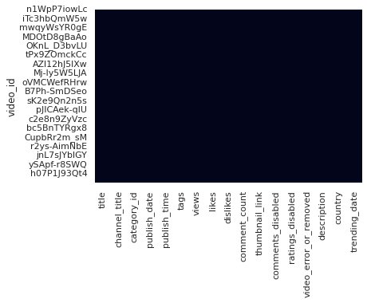

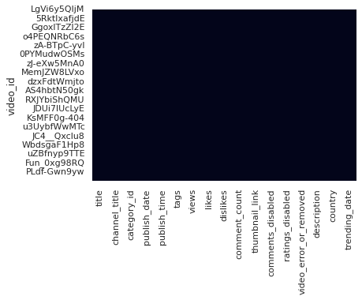

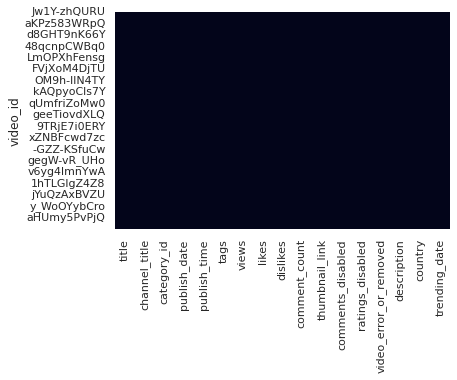

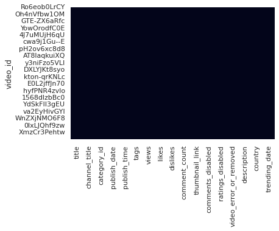

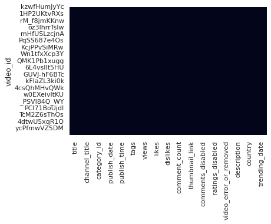

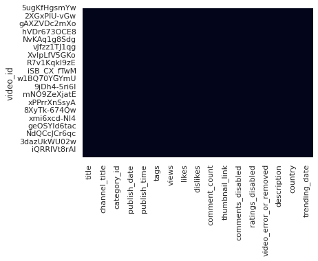

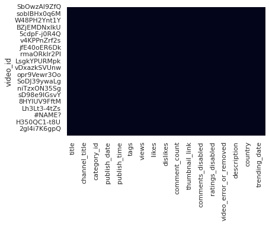

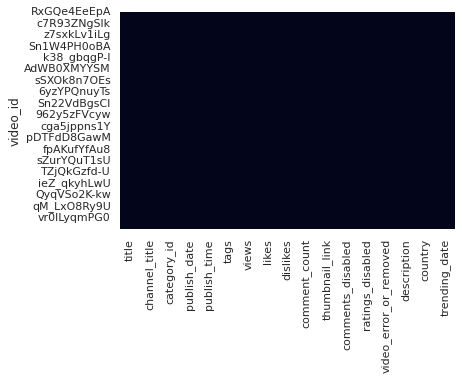

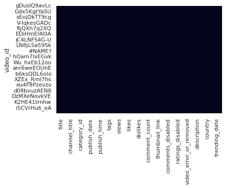

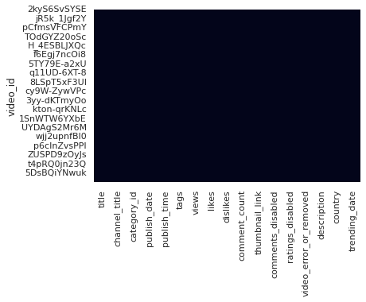

```python
for df in all_dataframes:
    sns.heatmap(df.isnull(), cbar=False)
    plt.figure(),
```

## **Concatinating Dataframes into one Dataframe**

Now, we have concatenated all countries' datasets into one dataframe in order to perform EDA. All necessary operations can be executed on this unified, clean dataset without any issues. We achieved this by using the concat() method to concatenate the datasets.

```python
combined_df = pd.concat(all_dataframes)
```

```python
combined_df.head()
```

| video_id | title | channel_title | category_id | publish_date | publish_time | tags | views | likes | dislikes | comment_count | thumbnail_link | comments_disabled | ratings_disabled | video_error_or_removed | description | country | trending_date |
| --- | --- | --- | --- | --- | --- | --- | --- | --- | --- | --- | --- | --- | --- | --- | --- | --- | --- |
| n1WpP7iowLc | Eminem - Walk On Water (Audio) ft. Beyoncé | EminemVEVO | 10 | 2017-11-10 | 17:00:03 | Eminem\|"Walk"\|"On"\|"Water"\|"Aftermath/Shady/In... | 17158579 | 787425 | 43420 | 125882 | https://i.ytimg.com/vi/n1WpP7iowLc/default.jpg | False | False | False | Eminem's new track Walk on Water ft. Beyoncé ... | CA | 2017-11-14 |
| 0dBIkQ4Mz1M | PLUSH - Bad Unboxing Fan Mail | iDubbbzTV | 23 | 2017-11-13 | 17:00:00 | plush\|"bad unboxing"\|"unboxing"\|"fan mail"\|"id... | 1014651 | 127794 | 1688 | 13030 | https://i.ytimg.com/vi/0dBIkQ4Mz1M/default.jpg | False | False | False | STill got a lot of packages. Probably will las... | CA | 2017-11-14 |
| 5qpjK5DgCt4 | Racist Superman \| Rudy Mancuso, King Bach & Le... | Rudy Mancuso | 23 | 2017-11-12 | 19:05:24 | racist superman\|"rudy"\|"mancuso"\|"king"\|"bach"... | 3191434 | 146035 | 5339 | 8181 | https://i.ytimg.com/vi/5qpjK5DgCt4/default.jpg | False | False | False | WATCH MY PREVIOUS VIDEO â¶ \n\nSUBSCRIBE âº ... | CA | 2017-11-14 |
| d380meD0W0M | I Dare You: GOING BALD!? | nigahiga | 24 | 2017-11-12 | 18:01:41 | ryan\|"higa"\|"higatv"\|"nigahiga"\|"i dare you"\|"... | 2095828 | 132239 | 1989 | 17518 | https://i.ytimg.com/vi/d380meD0W0M/default.jpg | False | False | False | I know it's been a while since we did this sho... | CA | 2017-11-14 |
| 2Vv-BfVoq4g | Ed Sheeran - Perfect (Official Music Video) | Ed Sheeran | 10 | 2017-11-09 | 11:04:14 | edsheeran\|"ed sheeran"\|"acoustic"\|"live"\|"cove... | 33523622 | 1634130 | 21082 | 85067 | https://i.ytimg.com/vi/2Vv-BfVoq4g/default.jpg | False | False | False | ð§: https://ad.gt/yt-perfect\nð°: https://... | CA | 2017-11-14 |

```python
# Making copy of original dataframe
backup_df = combined_df.reset_index().sort_values('trending_date', ascending=False).set_index('video_id')
```

Next, we made the decision to enhance the quality of our data by sorting the entries within the dataset based on the 'trending_date.' This action was taken to ensure that the most recent trending videos would appear at the top of the dataset. We implemented this sorting process to focus on the current trends of the videos in each country, as they are more relevant to our project. We repeated this operation for each of the individual dataframes within the list we had previously created.

```python
# Sorting according to latest trending date while removing duplicates
combined_df = combined_df.reset_index().sort_values('trending_date', ascending=False).drop_duplicates('video_id',keep='first').set_index('video_id')
for df in all_dataframes:
    df = df.reset_index().sort_values('trending_date', ascending=False).set_index('video_id')
```

```python
print("Combined dataframe")
combined_df[['publish_date','publish_time','trending_date', 'country']].head()
# It can be seen that latest publications and trending information is at the top now
```

```
Combined dataframe
```

| video_id | publish_date | publish_time | trending_date | country |
| --- | --- | --- | --- | --- |
| ooyjaVdt-jA | 2018-05-17 | 17:09:38 | 2018-06-14 | US |
| CtD7xLLNODg | 2018-06-13 | 12:00:00 | 2018-06-14 | DE |
| EQn2R3RVX74 | 2018-06-11 | 23:08:06 | 2018-06-14 | DE |
| ZX1OmtsOEm4 | 2018-06-13 | 08:46:31 | 2018-06-14 | DE |
| cdWw_VPglEs | 2018-06-12 | 11:30:03 | 2018-06-14 | DE |

### **Inserting Category Column**

reading randomly one json file to get insights from it's contents.

```python
with open('US_category_id.json', 'r') as f:
    data = f.read()
# parsing file
obj = json.loads(data)
```

We randomly selected JSON files, all of which contain similar data. Each JSON file contains IDs ranging from 1 to 44, inclusive. Alongside each ID, there is information related to its category, title, kind, and more. Consequently, we can choose any one of the JSON files to map the category to the category ID in our data frame. We have successfully mapped the category IDs into the combined data frame. Furthermore, we have performed the same insertion process for all the individual data frames.

```python
category_id = {}
with open('DE_category_id.json', 'r') as f:
    d = json.load(f)
    for category in d['items']:
        category_id[category['id']] = category['snippet']['title']
combined_df.insert(2, 'category', combined_df['category_id'].map(category_id))
backup_df.insert(2, 'category', backup_df['category_id'].map(category_id))
for df in all_dataframes:
    df.insert(2, 'category', df['category_id'].map(category_id))
# Printing cleaned combined dataframe
combined_df.head(3)
```

| video_id | title | channel_title | category | category_id | publish_date | publish_time | tags | views | likes | dislikes | comment_count | thumbnail_link | comments_disabled | ratings_disabled | video_error_or_removed | description | country | trending_date |
| --- | --- | --- | --- | --- | --- | --- | --- | --- | --- | --- | --- | --- | --- | --- | --- | --- | --- | --- |
| ooyjaVdt-jA | Official Call of Duty®: Black Ops 4 âÂ Mult... | Call of Duty | Gaming | 20 | 2018-05-17 | 17:09:38 | call of duty\|"cod"\|"activision"\|"Black Ops 4" | 10306119 | 357079 | 212976 | 144795 | https://i.ytimg.com/vi/ooyjaVdt-jA/default.jpg | False | False | False | Call of Duty: Black Ops 4 Multiplayer raises t... | US | 2018-06-14 |
| CtD7xLLNODg | Atomkraft erklärt: Wie funktioniert sie? (1/3) | Dinge Erklärt â Kurzgesagt | Science & Technology | 28 | 2018-06-13 | 12:00:00 | Atomkraft\|"Atomenergie"\|"Nuklear"\|"Atomwaffe"\|... | 54336 | 5407 | 33 | 525 | https://i.ytimg.com/vi/CtD7xLLNODg/default.jpg | False | False | False | Atomkraft ist ein schwieriges Thema. Die Gegne... | DE | 2018-06-14 |
| EQn2R3RVX74 | Benly - Whitehouse (Official Lyric Video) | MrOAKcheese | Music | 10 | 2018-06-11 | 23:08:06 | Benly\|"whitehouse"\|"chill music"\|"dope music" | 545468 | 1329 | 338 | 58 | https://i.ytimg.com/vi/EQn2R3RVX74/default.jpg | False | False | False | Official audio to Whitehouse performed by arti... | DE | 2018-06-14 |

Now, I have checked the unique catories in the combined_df.

```python
combined_df['category'].unique()
```

```
array(['Gaming', 'Science & Technology', 'Music', 'People & Blogs',
       'Entertainment', 'Comedy', 'Film & Animation', nan, 'Sports',
       'News & Politics', 'Education', 'Howto & Style',
       'Autos & Vehicles', 'Travel & Events', 'Pets & Animals', 'Shows',
       'Movies', 'Trailers'], dtype=object)
```

# **Exploratory Data Analysis**

- What is the likes-to-dislikes ratio in various categories?
- Which video category receives the most likes?
- Which videos are currently trending as the top five in each country?
- Is the video with the most likes also the most trending?
- Which category receives the most comments from users?

### **The like-dislike ratio in various categories**

We began our analysis by examining the ratio of likes to dislikes for a popular video in each category. A higher ratio indicates that users found the video's content more enjoyable. As depicted in the screenshot below, the results are as follows:

```python
# calculating total likes for each category
likesdf=combined_df.groupby('category')['likes'].agg('sum')

# calculating total dislikes for each category
dislikesdf = combined_df.groupby('category')['dislikes'].agg('sum')

# calculating ratios of likes to dislikes
ratiodf = likesdf/dislikesdf

# most liked category to appear on top
ratiodf = ratiodf.sort_values(ascending=False).reset_index()
```

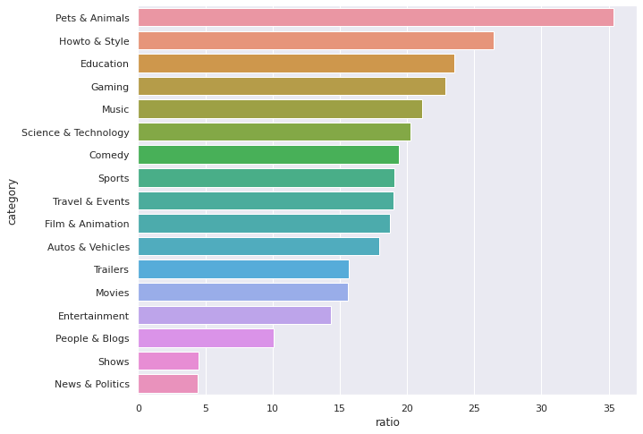

```python
# plotting bar chart
ratiodf.columns = ['category','ratio']
plt.subplots(figsize=(10, 8))
sns.barplot(x="ratio", y="category", data=ratiodf,
            label="Ratio of likes-dislikes in different categories")
```

Among the trending categories, it is evident that videos in the 'Pets and Animals' category have the highest ratio of likes to dislikes, whereas 'News' and 'Politics' videos have the lowest. From this, we can deduce that people are less divided on entertainment-centered videos compared to divisive topics like 'News,' which often leads to a split in user opinions.

### **More liked category**

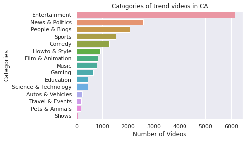

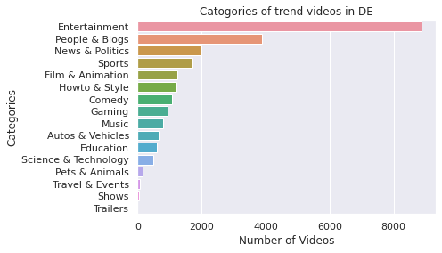

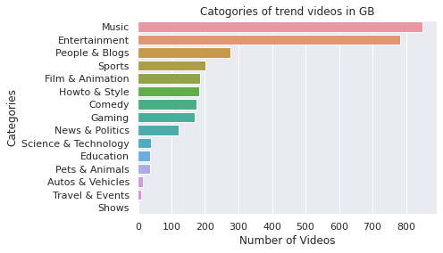

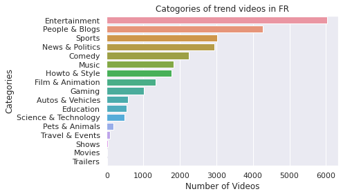

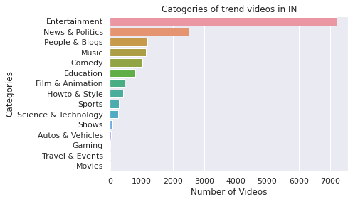

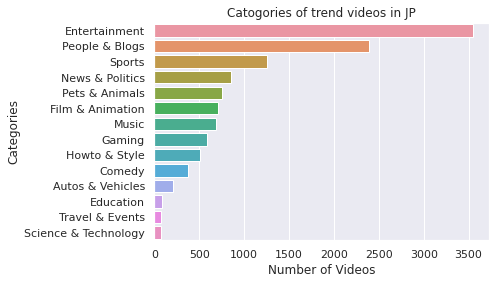

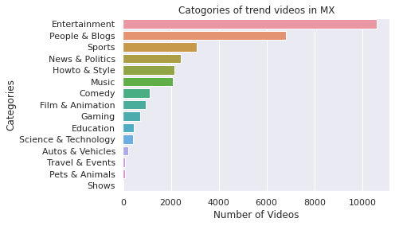

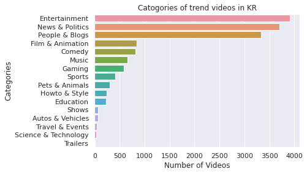

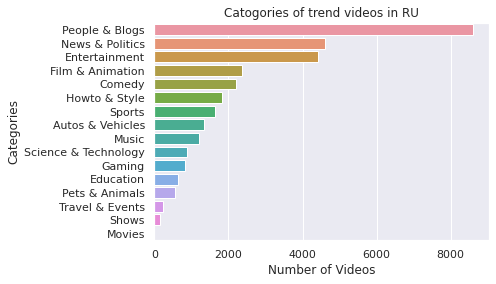

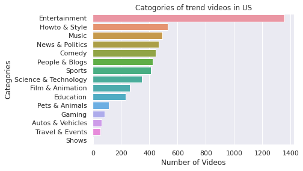

```python
# Getting names of all countries
countries = []
allcsv = [i for i in glob.glob('*.{}'.format('csv'))]
for csv in allcsv:
    c = csv[0:2]
    countries.append(c)
for country in countries:
    if country == 'US':
        tempdf = combined_df[combined_df['country']==country]['category'].value_counts().reset_index()
        ax = sns.barplot(y=tempdf['index'], x=tempdf['category'], data=tempdf, orient='h')
        plt.xlabel("Number of Videos")
        plt.ylabel("Categories")
        plt.title("Catogories of trend videos in " + country)
    else:
        tempdf = combined_df[combined_df['country']==country]['category'].value_counts().reset_index()
        ax = sns.barplot(y=tempdf['index'], x=tempdf['category'], data=tempdf, orient='h')
        plt.xlabel("Number of Videos")
        plt.ylabel("Categories")
        plt.title("Catogories of trend videos in " + country)
        plt.figure()
```

Except for RU (Russia) and GB (Great Britain), 'Entertainment' is the most popular category among users in all other countries. Russian viewers favor the 'People and Blogs' category, while British viewers prefer 'Music.' On the other hand, 'Shows,' 'Movies,' and 'Trailers' ranked as the least popular categories in almost every country.

n addition to RU and GB, 'Entertainment' stands out as the most preferred category among users in each of the other countries. Russian viewers favor the 'People and Blogs' category the most, while British viewers have a preference for 'Music.' Conversely, 'Shows,' 'Movies,' and 'Trailers' received the least amount of user engagement in nearly all countries.

## **Top 5 trending videos in each country**

```python
temporary = []
for df in all_dataframes:
    temp = df
    temp = temp.reset_index().sort_values(by = ['views'], ascending=False)
    temp.drop_duplicates(subset ="video_id", keep = 'first', inplace = True)
    temp.set_index('video_id', inplace=True)
    temp = temp.head(5)
    temporary.append(temp)
print("country " , set(temporary[0]['country']))
temporary[0][['title', 'channel_title', 'category', 'views', 'likes']]
```

```
country  {'CA'}
```

| video_id | title | channel_title | category | views | likes |
| --- | --- | --- | --- | --- | --- |
| FlsCjmMhFmw | YouTube Rewind: The Shape of 2017 \| #YouTubeRe... | YouTube Spotlight | Entertainment | 137843120 | 3014479 |
| VYOjWnS4cMY | Childish Gambino - This Is America (Official V... | ChildishGambinoVEVO | Music | 98938809 | 3037318 |
| 6ZfuNTqbHE8 | Marvel Studios' Avengers: Infinity War Officia... | Marvel Entertainment | Entertainment | 89930713 | 2606665 |
| 7C2z4GqqS5E | BTS (ë°©íìë ë¨) 'FAKE LOVE' Official MV | ibighit | Music | 80738011 | 5053338 |
| _I_D_8Z4sJE | Nicky Jam x J. Balvin - X (EQUIS) \| Video Ofic... | NickyJamTV | Music | 61163906 | 629164 |

```python
print("country " , set(temporary[2]['country']))
temporary[2][['title', 'channel_title', 'category', 'views', 'likes']]
```

```
country  {'GB'}
```

| video_id | title | channel_title | category | views | likes |
| --- | --- | --- | --- | --- | --- |
| _I_D_8Z4sJE | Nicky Jam x J. Balvin - X (EQUIS) \| Video Ofic... | NickyJamTV | Music | 424538912 | 2818771 |
| 9jI-z9QN6g8 | Te Bote Remix - Casper, Nio GarcÃa, Darell, N... | Flow La Movie | Music | 337621571 | 2581961 |
| kLpH1nSLJSs | Bad Bunny - Amorfoda \| Video Oficial | Bad Bunny | Music | 328860380 | 3823879 |
| wfWkmURBNv8 | Ozuna x Romeo Santos - El Farsante Remix | Ozuna | Music | 288811992 | 1618180 |
| VYOjWnS4cMY | Childish Gambino - This Is America (Official V... | ChildishGambinoVEVO | Music | 259721696 | 5444541 |

```python
print("country " , set(temporary[4]['country']))
temporary[4][['title', 'channel_title', 'category', 'views', 'likes']]
```

```
country  {'IN'}
```

| video_id | title | channel_title | category | views | likes |
| --- | --- | --- | --- | --- | --- |
| FlsCjmMhFmw | YouTube Rewind: The Shape of 2017 \| #YouTubeRe... | YouTube Spotlight | Entertainment | 125432237 | 2912710 |
| 6ZfuNTqbHE8 | Marvel Studios' Avengers: Infinity War Officia... | Marvel Entertainment | Entertainment | 89930713 | 2606663 |
| u9Mv98Gr5pY | VENOM - Official Trailer (HD) | Sony Pictures Entertainment | Entertainment | 53822757 | 1250535 |
| QwievZ1Tx-8 | Marvel Studios' Avengers: Infinity War - Offic... | Marvel Entertainment | Entertainment | 45064699 | 1494997 |
| rRr1qiJRsXk | Sanju \| Official Teaser \| Ranbir Kapoor \| Rajk... | FoxStarHindi | Entertainment | 44171797 | 780895 |

Users from every nation prefer videos in the categories of 'Music' and 'Entertainment,' which might indicate that users prefer to utilise the network for recreational purposes over other functions.

### **most liked video also the most trending video**

Knowing which countries prefer specific trending videos, a question arose: Is the most trending video in that nation also the most liked video?

```python
temporary = []
for df in all_dataframes:
    temp = df
    temp = temp.reset_index().sort_values(by = ['likes'], ascending=False)
    temp.drop_duplicates(subset ="video_id", keep = 'first', inplace = True)
    temp.set_index('video_id', inplace=True)
    temp = temp.head(5)
    temporary.append(temp)
temporary[0][['views', 'likes']]
```

| video_id | views | likes |
| --- | --- | --- |
| 7C2z4GqqS5E | 80738011 | 5053338 |
| VYOjWnS4cMY | 98938809 | 3037318 |
| FlsCjmMhFmw | 137843120 | 3014479 |
| 6ZfuNTqbHE8 | 89930713 | 2606665 |
| kTlv5_Bs8aw | 27670973 | 2542863 |

```python
temporary[2][['views', 'likes']]
```

| video_id | views | likes |
| --- | --- | --- |
| 7C2z4GqqS5E | 123010920 | 5613827 |
| VYOjWnS4cMY | 259721696 | 5444541 |
| xpVfcZ0ZcFM | 258164991 | 4737873 |
| kLpH1nSLJSs | 328860380 | 3823879 |
| ffxKSjUwKdU | 208876887 | 3394437 |

```python
temporary[4][['views', 'likes']]
```

| video_id | views | likes |
| --- | --- | --- |
| FlsCjmMhFmw | 125432237 | 2912710 |
| 6ZfuNTqbHE8 | 89930713 | 2606663 |
| dfnCAmr569k | 42019590 | 1804377 |
| 2Vv-BfVoq4g | 39082222 | 1721384 |
| tCXGJQYZ9JA | 43738208 | 1658756 |

While it may not seem evident at first, our exploration of the dataset and accompanying materials revealed that the video with the most likes is not necessarily the one that trends the most. This became even more apparent as we delved deeper into the data, consistently finding that the most trending videos are often the most viewed ones.

### **Users like videos from which category more**

We also chose to determine which category received the most likes among all the categories.

```python
temp = combined_df
temp = temp.groupby('category')['views', 'likes'].apply(lambda x: x.astype(int).sum())
temp = temp.sort_values(by='likes', ascending=False).head()
temp
```

| category | views | likes |
| --- | --- | --- |
| Entertainment | 17587558297 | 471868512 |
| Music | 18175199260 | 444810347 |
| Comedy | 4577350247 | 219096188 |
| People & Blogs | 5606736247 | 157767434 |
| Howto & Style | 2215633514 | 77250723 |

### **Users most commented category**

to explore which category overall gets the most comments.

```python
temp = combined_df
temp = temp.groupby('category')['views','likes', 'comment_count'].apply(lambda x: x.astype(int).sum())
temp = temp.sort_values(by='comment_count', ascending=False).head()
temp
```

| category | views | likes | comment_count |
| --- | --- | --- | --- |
| Entertainment | 17587558297 | 471868512 | 68369799 |
| Music | 18175199260 | 444810347 | 36232019 |
| People & Blogs | 5606736247 | 157767434 | 24662973 |
| Comedy | 4577350247 | 219096188 | 23326468 |
| News & Politics | 3470585459 | 53466729 | 14956548 |

### **Correlation between views, comments, likes, and dislikes**

Next, we decided to determine whether there was any correlation between views, likes, dislikes, and comments.

```
                  views  comment_count     likes  dislikes
views          1.000000       0.423581  0.768309  0.378175
comment_count  0.423581       1.000000  0.700536  0.667465
likes          0.768309       0.700536  1.000000  0.435378
dislikes       0.378175       0.667465  0.435378  1.000000
```

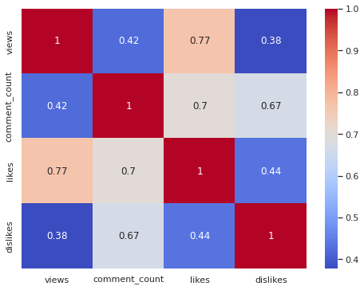

```python
col = ['views', 'comment_count', 'likes', 'dislikes']
corr = combined_df[col].corr()
print(corr)

correlations = combined_df[col].corr(method='pearson')
plt.figure(figsize=(8, 6))
sns.heatmap(correlations, cmap="coolwarm", annot=True)
plt.show()
```

When calculating the correlation among all the variables, we also consider the correlation of each feature with itself, which is always 1. This explains why the graph consistently displays a red diagonal line from the upper left to the lower right.

The data reveal that views and likes, likes and comment count, as well as dislikes and comment count, all exhibit a positive relationship. We reached this conclusion because a positive relationship exists whenever the correlation coefficient, denoted as 'corr,' is greater than zero.

### **Machine learning Algorithms**

After data analysis, we decided to move onto Machine learnign algorithms.

Defining the dependent variable

```python
df = all_dataframes[0]
df
y = df.views
```

### **Importing Libraries**

```python
from sklearn import linear_model
from sklearn.metrics import roc_auc_score
import random
from sklearn.model_selection import train_test_split
from sklearn import metrics
```

Data was initially split into an 80/20 ratio to create training and test sets

```python
x_train, x_test, y_train, y_test = train_test_split(df, y, test_size=0.2)
```

In both the train and test data, we used likes and dislikes as the independent variables (x-axis) to observe their impact on views.

```python
predictors = ["likes","dislikes"]
x_train = x_train[predictors]
x_test = x_test[predictors]
```

### **Linear regression**

We used linear model, a built-in function for linear regression. LinearRegression() is used to train the model using our training data, and x test is used to predict test views using the likes in the test data.

```python
lm = linear_model.LinearRegression()
model = lm.fit(x_train, y_train)
predictions = model.predict(x_test)
# To retrieve the intercept
print(lm.intercept_)
# For retrieving the slope
print('regressor coffecient:',lm.coef_)
```

```
334427.5427703344
regressor coffecient: [18.30474879 40.84028291]
```

### **Plotting the Linear Regression results**

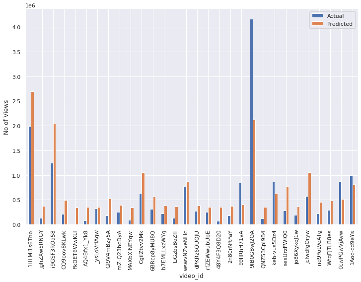

```python
df = pd.DataFrame({'Actual': y_test, 'Predicted': predictions})
df1 = df.head(30)
df1.plot(kind='bar',figsize=(12,8))
plt.ylabel("No of Views")
plt.show()
```

From the plot above, it's evident that our predicted views are often not far from the actual views received by the videos, indicating that our model is working.

### **DecisionTreeRegressor**

We have used DecisionTreeRegressor() to train the model using our training data, and x test is used to predict test views using the likes in the test data.

```python
from sklearn.tree import DecisionTreeRegressor
dtr = DecisionTreeRegressor()
dtr_model = dtr.fit(x_train, y_train)
dtr_predictions = dtr_model.predict(x_test)
```

### **Plotting the Decision Tree Regressor results**

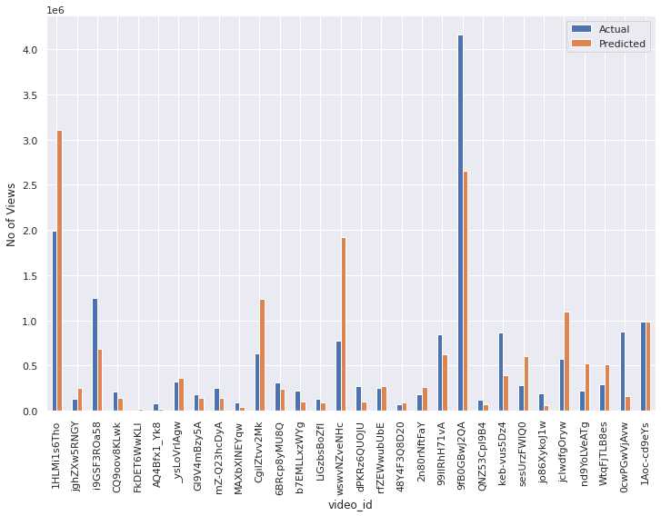

```python
df = pd.DataFrame({'Actual': y_test, 'Predicted': dtr_predictions})
df1 = df.head(30)
df1.plot(kind='bar',figsize=(12,8))
plt.ylabel("No of Views")
plt.show()
```

### **RandomForestRegressor**

```python
from sklearn.ensemble import RandomForestRegressor
rfr_model = RandomForestRegressor()
rfr_model = dtr.fit(x_train, y_train)
rfr_predictions = rfr_model.predict(x_test)
```

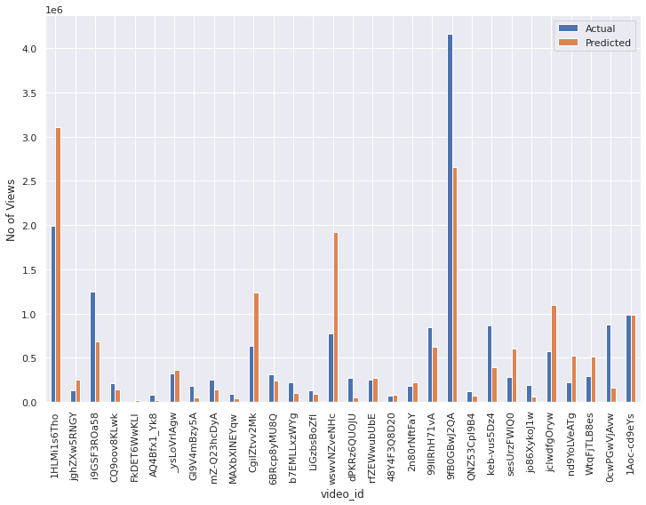

```python
df = pd.DataFrame({'Actual': y_test, 'Predicted': rfr_predictions})
df1 = df.head(30)
df1.plot(kind='bar',figsize=(12,8))
plt.ylabel("No of Views")
plt.show()
```